# Homework exercise 3

## Simulation

We will be simulating an arma model with p=2 and q=1.  
The model is Xt = 0.5BXt+0.3B^2Xt+et+0.7Bet.  
It will be simulated 1000 times and with a size of 500 observations.  
var(e) = 1 will be used for simplicity

```r
library(tseries)
library(forecast)
set.seed(201500)
```

We want to get the number of times each model was selected by AIC and BIC.  
So we start by creating the tables that will hold said times.

```r
sumAIC = matrix(0L,nrow = 6 ,ncol = 6)
sumBIC = matrix(0L,nrow = 6 ,ncol = 6)
```

Next we need to simulate the series.

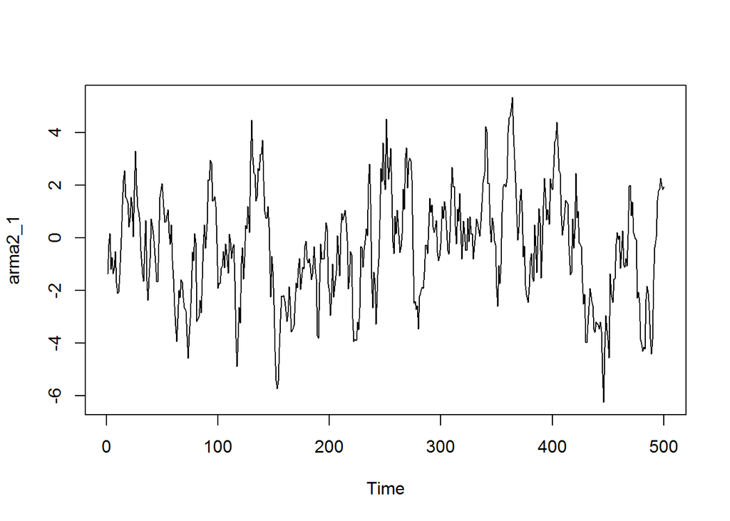

```r
  p = 2
  q = 1
  a1 = 0.5
  a2 = 0.3
  b1 = 0.7
  n = 500
  sd= 1
  arma2_1 = arima.sim(list(order=c(p,0,q),ar=c(a1,a2),ma=c(b1)),n=n,sd=sd)
  ts.plot(arma2_1)
```

Now that we have the simulated series we need to estimate the parameters.  
We will use the auto.arima function

```r
  #To get the estimation for AIC

  #ic = "aic" minimizes the AIC
  #max.d = 0 because the series is not differenced
  fitAIC = auto.arima(arma2_1,ic="aic",max.d = 0)
  AICOrders = arimaorder(fitAIC)
  AICp = AICOrders[1]+1
  AICq = AICOrders[3]+1
  sumAIC[AICp,AICq]=sumAIC[AICp,AICq]+1

  #To get the estimation for BIC

  #ic = "bic" minimizes the BIC
  #max.d = 0 because the series is not differenced
  fitBIC = auto.arima(arma2_1,ic="bic",max.d = 0)
  BICOrders = arimaorder(fitBIC)
  BICp = BICOrders[1]+1
  BICq = BICOrders[3]+1
  sumBIC[BICp,BICq]=sumBIC[BICp,BICq]+1

  print(sumAIC)
```

```
##      [,1] [,2] [,3] [,4] [,5] [,6]
## [1,]    0    0    0    0    0    0
## [2,]    0    0    0    1    0    0
## [3,]    0    0    0    0    0    0
## [4,]    0    0    0    0    0    0
## [5,]    0    0    0    0    0    0
## [6,]    0    0    0    0    0    0
```

```r
  print(sumBIC)
```

```
##      [,1] [,2] [,3] [,4] [,5] [,6]
## [1,]    0    0    0    0    0    0
## [2,]    0    0    0    0    0    0
## [3,]    0    1    0    0    0    0
## [4,]    0    0    0    0    0    0
## [5,]    0    0    0    0    0    0
## [6,]    0    0    0    0    0    0
```

We obtained the values for a single sample, however we want them for 1000.  
As such lets run the previous code 999 more times.

```r
  for (i in 1:999){
    arma2_1 = arima.sim(list(order=c(p,0,q),ar=c(a1,a2),ma=c(b1)),n=n,sd=sd)

    fitAIC = auto.arima(arma2_1,ic="aic",max.d = 0)
    AICOrders = arimaorder(fitAIC)
    AICp = AICOrders[1]+1
    AICq = AICOrders[3]+1
    sumAIC[AICp,AICq]=sumAIC[AICp,AICq]+1

    fitBIC = auto.arima(arma2_1,ic="bic",max.d = 0)
    BICOrders = arimaorder(fitBIC)
    BICp = BICOrders[1]+1
    BICq = BICOrders[3]+1
    sumBIC[BICp,BICq]=sumBIC[BICp,BICq]+1
  }
  print(sumAIC)
```

```
##      [,1] [,2] [,3] [,4] [,5] [,6]
## [1,]    0    0    0    0    0    0
## [2,]    0   36  285   86   12    2
## [3,]    0  362   30   21    9    1
## [4,]    2   46   38   16    5    1
## [5,]    3   16    7    9    3    1
## [6,]    1    2    3    1    0    2
```

```r
  print(sumBIC)
```

```
##      [,1] [,2] [,3] [,4] [,5] [,6]
## [1,]    0    0    0    0    0    0
## [2,]    0  274  259   29    0    0
## [3,]    0  424    0    0    0    0
## [4,]    1    9    3    0    0    0
## [5,]    1    0    0    0    0    0
## [6,]    0    0    0    0    0    0
```